# Préambule

Mettre tous les fichiers nécessaires au programme dans un même répertoire et changer le répertoire de travail permettra de traveiller uniquement avec les noms des fichiers. L'ajout du chemin d'accès (long et source d'erreur) ne sera pas utile. Pour ceci, il suffit d'executer la commande suivante :

```r
path = "D:/Thèse boulot/1ère année/cours MSI 2ème année/Coorection TP MSI/TPmaison"
setwd(path)
getwd()
```

'D:/Thèse boulot/1ère année/cours MSI 2ème année/Coorection TP MSI/TPmaison'

# Partie 1 : Prise en main de l'outil

**Question 1 :** Création d'un vecteur et utilisation de diverses fonctions

- Création d'un vecteur de dix valeurs manuellement

```r
vect = c(1,8,5,6,9,7,3,4,2,0)
vect <- c(1,8,5,6,9,7,3,4,2,0) # Equivalent : <- équivaut à =
vect
```

1. 1

2. 8

3. 5

4. 6

5. 9

6. 7

7. 3

8. 4

9. 2

10. 0

- Vecteur de dix 1

```r
c(rep(1,10))
```

1. 1

2. 1

3. 1

4. 1

5. 1

6. 1

7. 1

8. 1

9. 1

10. 1

- Vecteur allant de a à b avec un pas de c

```r
c(seq(1,5,0.5))
```

1. 1

2. 1.5

3. 2

4. 2.5

5. 3

6. 3.5

7. 4

8. 4.5

9. 5

- Multiplication d'un vecteur par une constante :

```r
vect*10
```

1. 10

2. 80

3. 50

4. 60

5. 90

6. 70

7. 30

8. 40

9. 20

10. 0

- Type d'une variable (numeric, character, data.frame, ...) :

```r
str(vect)
```

```
 num [1:10] 1 8 5 6 9 7 3 4 2 0
```

- Caractéristiques du vecteur :

- Inverse l'ordre des éléments

```r
rev(vect)
```

1. 0

2. 2

3. 4

4. 3

5. 7

6. 9

7. 6

8. 5

9. 8

10. 1

- Tri les valeurs du vecteur par ordre croissant

```r
sort(vect, decreasing = FALSE) #(decreasing = TRUE : tri par ordre décroissant)
```

1. 0

2. 1

3. 2

4. 3

5. 4

6. 5

7. 6

8. 7

9. 8

10. 9

- Renvoie les positions des éléments du vecteur triés

```r
order(vect) #l'argument decreasing peut aussi être ajouté
```

1. 10

2. 1

3. 9

4. 7

5. 8

6. 3

7. 4

8. 6

9. 2

10. 5

**Question 2 :** Création de matrices carrées de taille $2*2$

```r
mat1 = matrix(c(1,5,8,9), nrow=2, ncol=2)
mat1
```

| 1 | 8 |
| --- | --- |
| 5 | 9 |

```r
mat2 = matrix(c(7,4,1,6), nrow=2, ncol=2, byrow=TRUE) # Le remplissage de la matrice s'effectue par ligne col1 = 7,1 col2 = 4,6 au lieu d'un remplissage par colonne col1 = 7,4 col2=1,6
mat2
```

| 7 | 4 |
| --- | --- |
| 1 | 6 |

- Concaténation en ligne de matrices :

```r
rbind(mat1, mat2) # En ligne
```

| 1 | 8 |
| --- | --- |
| 5 | 9 |
| 7 | 4 |
| 1 | 6 |

- Concaténation en colonne de matrices :

```r
cbind(mat1, mat2) # En ligne
```

| 1 | 8 | 7 | 4 |
| --- | --- | --- | --- |
| 5 | 9 | 1 | 6 |

- Produit de matrices :

```r
mat1 %*% mat2 # /!\ * multiplie les termes de la matrice terme à terme et ne correspond pas au produit matriciel
```

| 15 | 52 |
| --- | --- |
| 44 | 74 |

**Question3 :** Appel du jeu de données Iris chargé en mémoire et présentation de ces dernières

```r
data(iris) # Chargement
str(iris) # Type de la variable et des colonnes qui la compose (data.frame de 150 observation pour 5 variable : tableau 150 * 5)
```

```
'data.frame':	150 obs. of  5 variables:
 $ Sepal.Length: num  5.1 4.9 4.7 4.6 5 5.4 4.6 5 4.4 4.9 ...
 $ Sepal.Width : num  3.5 3 3.2 3.1 3.6 3.9 3.4 3.4 2.9 3.1 ...
 $ Petal.Length: num  1.4 1.4 1.3 1.5 1.4 1.7 1.4 1.5 1.4 1.5 ...
 $ Petal.Width : num  0.2 0.2 0.2 0.2 0.2 0.4 0.3 0.2 0.2 0.1 ...
 $ Species     : Factor w/ 3 levels "setosa","versicolor",..: 1 1 1 1 1 1 1 1 1 1 ...
```

- Résumé du jeu de données :

```r
summary(iris) # Résumé du jeu de données
```

```
  Sepal.Length    Sepal.Width     Petal.Length    Petal.Width
 Min.   :4.300   Min.   :2.000   Min.   :1.000   Min.   :0.100
 1st Qu.:5.100   1st Qu.:2.800   1st Qu.:1.600   1st Qu.:0.300
 Median :5.800   Median :3.000   Median :4.350   Median :1.300
 Mean   :5.843   Mean   :3.057   Mean   :3.758   Mean   :1.199
 3rd Qu.:6.400   3rd Qu.:3.300   3rd Qu.:5.100   3rd Qu.:1.800
 Max.   :7.900   Max.   :4.400   Max.   :6.900   Max.   :2.500
       Species
 setosa    :50
 versicolor:50
 virginica :50
```

- Boite à moustache sur les données :

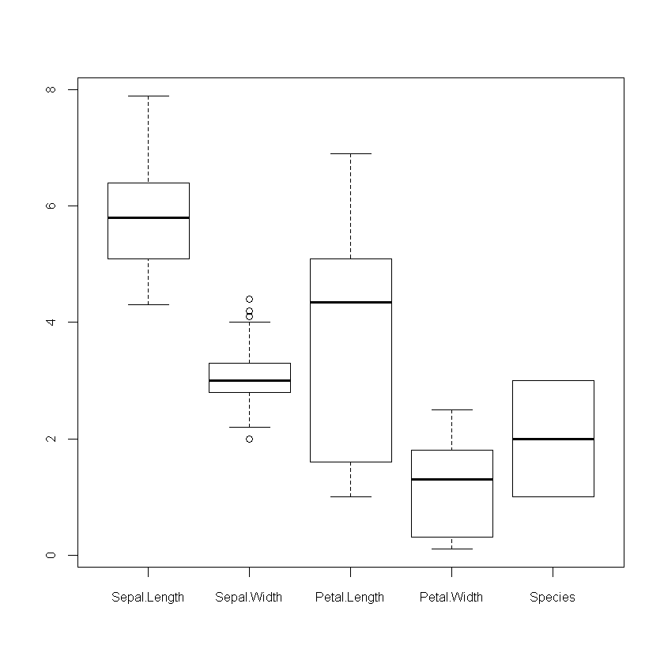

```r
boxplot(iris, cex.axis=0.8) # cex.axis détermine la taille d'écriture des axes
```

- Accès à une colonne du dataframe iris :

```r
iris$Sepal.Length # Renvoie les valeurs de la colonne Sepal.Length
```

1. 5.1

2. 4.9

3. 4.7

4. 4.6

5. 5

6. 5.4

7. 4.6

8. 5

9. 4.4

10. 4.9

11. 5.4

12. 4.8

13. 4.8

14. 4.3

15. 5.8

16. 5.7

17. 5.4

18. 5.1

19. 5.7

20. 5.1

21. 5.4

22. 5.1

23. 4.6

24. 5.1

25. 4.8

26. 5

27. 5

28. 5.2

29. 5.2

30. 4.7

31. 4.8

32. 5.4

33. 5.2

34. 5.5

35. 4.9

36. 5

37. 5.5

38. 4.9

39. 4.4

40. 5.1

41. 5

42. 4.5

43. 4.4

44. 5

45. 5.1

46. 4.8

47. 5.1

48. 4.6

49. 5.3

50. 5

51. 7

52. 6.4

53. 6.9

54. 5.5

55. 6.5

56. 5.7

57. 6.3

58. 4.9

59. 6.6

60. 5.2

61. 5

62. 5.9

63. 6

64. 6.1

65. 5.6

66. 6.7

67. 5.6

68. 5.8

69. 6.2

70. 5.6

71. 5.9

72. 6.1

73. 6.3

74. 6.1

75. 6.4

76. 6.6

77. 6.8

78. 6.7

79. 6

80. 5.7

81. 5.5

82. 5.5

83. 5.8

84. 6

85. 5.4

86. 6

87. 6.7

88. 6.3

89. 5.6

90. 5.5

91. 5.5

92. 6.1

93. 5.8

94. 5

95. 5.6

96. 5.7

97. 5.7

98. 6.2

99. 5.1

100. 5.7

101. 6.3

102. 5.8

103. 7.1

104. 6.3

105. 6.5

106. 7.6

107. 4.9

108. 7.3

109. 6.7

110. 7.2

111. 6.5

112. 6.4

113. 6.8

114. 5.7

115. 5.8

116. 6.4

117. 6.5

118. 7.7

119. 7.7

120. 6

121. 6.9

122. 5.6

123. 7.7

124. 6.3

125. 6.7

126. 7.2

127. 6.2

128. 6.1

129. 6.4

130. 7.2

131. 7.4

132. 7.9

133. 6.4

134. 6.3

135. 6.1

136. 7.7

137. 6.3

138. 6.4

139. 6

140. 6.9

141. 6.7

142. 6.9

143. 5.8

144. 6.8

145. 6.7

146. 6.7

147. 6.3

148. 6.5

149. 6.2

150. 5.9

**Question 4 :** Fonctions graphiques de R (cf. Table 7 : http://maths.cnam.fr/IMG/pdf/poly_R_deuxiemepartie.pdf ou help(plot))

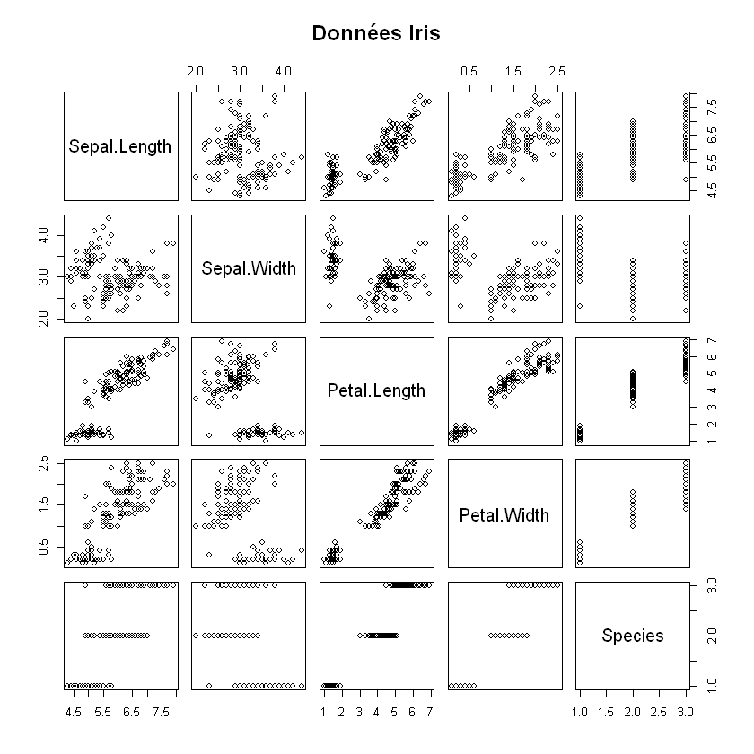

```r
plot(iris, main = "Données Iris")
```

- Exemple (moche) montrant les différentes posssibilités graphiques :

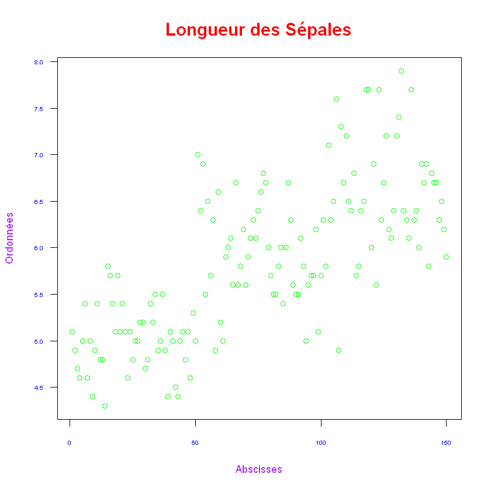

```r
plot(iris$Sepal.Length, main = "Longueur des Sépales", xlab = 'Abscisses', ylab = 'Ordonnées', cex.axis = 0.5, cex.lab=0.9, cex.main = 1.5, col.axis = 'blue', col.main = 'red', col.lab = 'purple', col = 'green', las=1)
#las permet de changer l'orientation des valeurs des axes
```

- Autre exemple de plot :

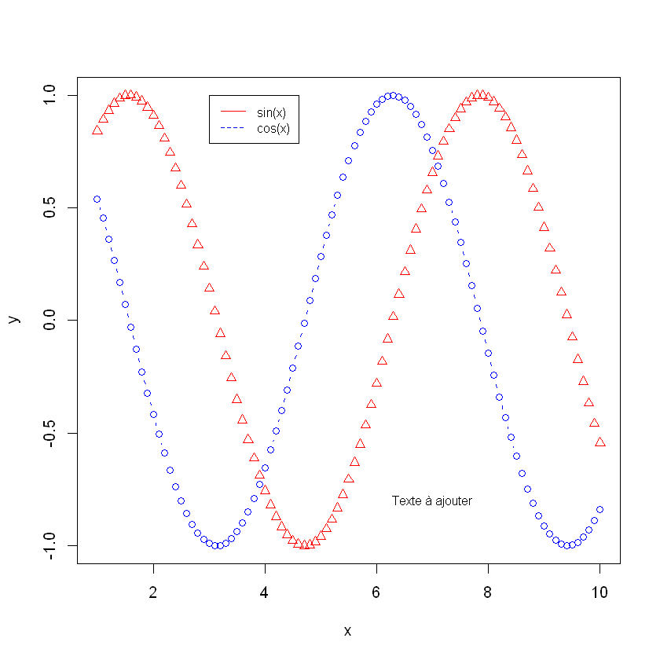

```r
x <- c(seq(1,10,0.1)); y1=sin(x); y2=cos(x) # Définition des valeurs
plot(x, y1,  pch=2, col="red", xlab="x", ylab="y") # pch définit la forme des points
lines(x, y2, pch=1, col="blue", type="b", lty=2) # Ajout d'une seconde ligne (type définit s'il s'agit de points liés ou de points isolés)
legend(x=3, y=1, legend=c("sin(x)", "cos(x)"), col=c("red", "blue"), lty=1:2, cex=0.8) # x et y sont indispensables et déterminent la position de la légende sur la figure
text(x=7, y=-0.8, 'Texte à ajouter', cex=0.8) # x et y sont encore indispensables
```

# Partie 2 : Analyse de données démographiques

**Question 1:** Import des données, mise en forme et résumés :

- Import des données

```r
data = read.csv('MSI_TPhome.csv', sep = ';') # Le chemin d'accès n'est pas nécessaire puisque nous avons définis notre environnement de travail (setwd) - Le séparateur est à définir suivant la forme du csv d'entrée (majoritairement : , ou ;)
```

- Renomer le nom des colonnes

```r
names(data)=c('Pays', 'CO2/hab', 'SurfaceForet(kha)', 'PIB/hab', 'IndiceSante', 'EsperanceVie', 'Population', 'TauxMortalite>5ans') # Permet de renommer les colonnes du data.frame
```

- Type de données

```r
str(data)
```

```
'data.frame':	169 obs. of  8 variables:
 $ Pays              : Factor w/ 169 levels "Albania","Algeria",..: 1 2 3 4 5 6 7 8 9 10 ...
 $ CO2/hab           : num  3.6 14 2.5 16.5 14 ...
 $ SurfaceForet(kha) : int  769 1579 59728 10 31861 304 15492 3838 936 0 ...
 $ PIB/hab           : int  4805 6087 2569 13928 1028 2294 29763 31697 249 23294 ...
 $ IndiceSante       : num  0.854 0.79 0.398 0.804 0.848 0.807 0.939 0.916 0.739 0.847 ...
 $ EsperanceVie      : num  74.2 70.1 45.2 70.9 73.8 71.2 79.5 78.1 66.9 73.7 ...
 $ Population        : num  3071.9 30533.8 13926.4 77.7 36930.7 ...
 $ TauxMortalite>5ans: int  27 46 212 19 21 36 6 5 69 13 ...
```

Le type de Pays est *Factor*, nous le transformont en caractères :

```r
data$Pays = as.character(data$Pays)
str(data)
```

```
'data.frame':	169 obs. of  8 variables:
 $ Pays              : chr  "Albania" "Algeria" "Angola" "Antigua and Barbuda" ...
 $ CO2/hab           : num  3.6 14 2.5 16.5 14 ...
 $ SurfaceForet(kha) : int  769 1579 59728 10 31861 304 15492 3838 936 0 ...
 $ PIB/hab           : int  4805 6087 2569 13928 1028 2294 29763 31697 249 23294 ...
 $ IndiceSante       : num  0.854 0.79 0.398 0.804 0.848 0.807 0.939 0.916 0.739 0.847 ...
 $ EsperanceVie      : num  74.2 70.1 45.2 70.9 73.8 71.2 79.5 78.1 66.9 73.7 ...
 $ Population        : num  3071.9 30533.8 13926.4 77.7 36930.7 ...
 $ TauxMortalite>5ans: int  27 46 212 19 21 36 6 5 69 13 ...
```

- Dimensions des données

```r
dim(data)
```

1. 169

2. 8

Il y a 169 observations (pays) et 8 colonnes (Pays, Co2/hab ...)

- Résumé statistique des données

```r
summary(data)
```

```
     Pays              CO2/hab       SurfaceForet(kha)    PIB/hab
 Length:169         Min.   :  0.10   Min.   :     0    Min.   :   34
 Class :character   1st Qu.:  2.00   1st Qu.:   342    1st Qu.: 1574
 Mode  :character   Median :  7.80   Median :  2768    Median : 4666
                    Mean   : 17.36   Mean   : 22233    Mean   : 9793
                    3rd Qu.: 22.90   3rd Qu.: 11725    3rd Qu.:12112
                    Max.   :206.50   Max.   :809269    Max.   :62111
  IndiceSante      EsperanceVie     Population        TauxMortalite>5ans
 Min.   :0.3120   Min.   :39.80   Min.   :     46.1   Min.   :  4.0
 1st Qu.:0.6260   1st Qu.:59.70   1st Qu.:   2385.0   1st Qu.: 13.0
 Median :0.7920   Median :70.20   Median :   6517.8   Median : 33.0
 Mean   :0.7342   Mean   :66.55   Mean   :  35081.0   Mean   : 58.8
 3rd Qu.:0.8530   3rd Qu.:74.10   3rd Qu.:  23414.9   3rd Qu.: 93.0
 Max.   :0.9650   Max.   :81.20   Max.   :1269116.7   Max.   :250.0
```

**Question 2 :** Diagramme baton et histogramme

- Diagramme baton de la population par pays :

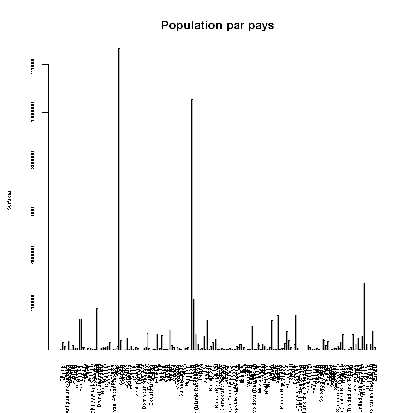

```r
barplot(data$'Population', ylab="Surfaces", names.arg = data$Pays, cex.names = 0.5, cex.axis = 0.5, las=3, cex.lab=0.5, main='Population par pays')
```

- Histogramme des hectars de forêt par pays :

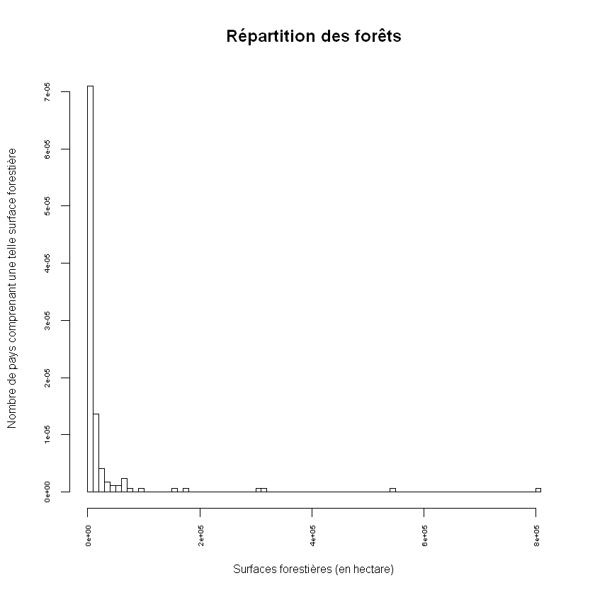

```r
hist(data$'SurfaceForet(kha)', ylab="Nombre de pays comprenant une telle surface forestière", xlab="Surfaces forestières (en hectare)", breaks = 100, freq=FALSE, cex.lab=0.8, cex.axis=0.5, las=3, main='Répartition des forêts')
# breaks définit le nombres de classes (barres)
```

Nous remarquons que la majorité des pays étudiés possèdent une faible surface forestière (première barre).

**Question 3 :** boîte à moustaches de l’espérance de vie et du taux de mortalité des moins de 5 ans

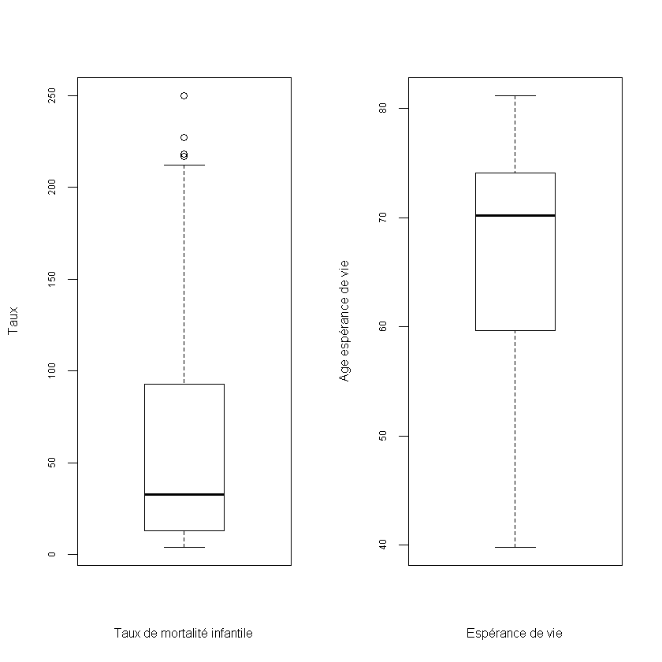

```r
par(mfrow = c(1,2)) # Permet de ploter deux graphes à côté
boxplot(data$'TauxMortalite>5ans', ylab='Taux', xlab='Taux de mortalité infantile', cex.axis=0.6, cex.lab=0.8)
boxplot(data$EsperanceVie, ylab='Age espérance de vie', xlab='Espérance de vie', cex.axis=0.6, cex.lab=0.8)
```

Les médianes sont représentès par les barres en gras et le rectange délimite les quartiles. Les valeurs extrêmes sont délimités par les traits horizontaux reliés à la boite par des pointillés. Les points présents pour la mortalité infantiles correspondent à des valeurs "aberrantes".

**Question 4 :** Définition d'une variable richesse (/!\ éviter les boucles qui augmentent le temps de calcul)

- Création d'une nouvelle colonne richesse

```r
data$Richesse[data$'PIB/hab'<1000] = 'pauvre' # Englobe toutes les lignes selon la condition définie entre crochet et affecte une valeur à la colonne créée Richesse
data$Richesse[data$'PIB/hab'>1000  & data$'PIB/hab'<40000] = 'moyen'
data$Richesse[data$'PIB/hab'>40000] = 'riche'
```

- Répartion des pays en fonction de leur "richesse"

```r
values = (table(data$Richesse))
values
```

```
 moyen pauvre  riche
   139     25      5
```

- Représenation à l'aide d'un diagramme camembert :

[figure not shown]

```r
pie(values, main='Proportion des pays riche, moyen et pauvre en fonction de leur PIB', labels=c('Pays pauvres', 'Pays moyens', 'Pays riches'), cex.main=0.8, cex=0.4)
```

**Question 5 :** Centrage-réduction de la variable : Population

**Question 6 :** Nuage de points

- Nuage de points de la variable indice de santé et emission de carbone :

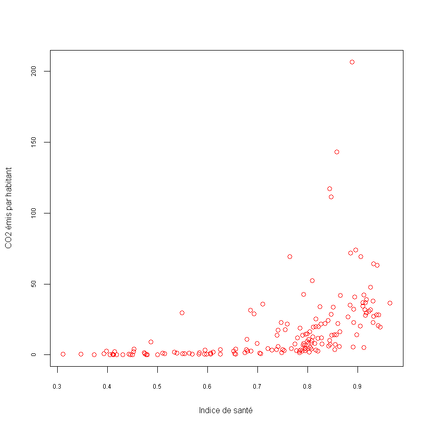

```r
plot(data$IndiceSante, data$'CO2/hab', xlab='Indice de santé', ylab='CO2 émis par habitant', cex.lab=0.8, cex.axis=0.6, col='red')
```

```r
coeff_corr = cor(data$IndiceSante, data$'CO2/hab', method='pearson')
```

- Nuage de points de la variable indice de santé et éspérance de vie :

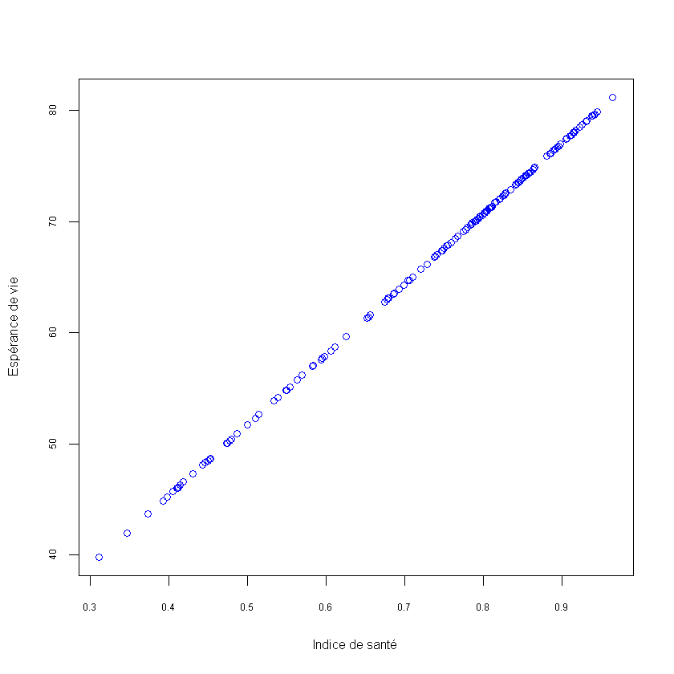

```r
plot(data$IndiceSante, data$EsperanceVie, xlab='Indice de santé', ylab='Espérance de vie', cex.lab=0.8, cex.axis=0.6, col='blue')
```

```r
coeff_corr2 =  cor(data$IndiceSante, data$EsperanceVie, method='pearson')
```

L'espérance de vie et l'indice de santé sont très fortement corrélés tandis que le CO2 émis par habitants et l'indice de santé le sont beaucoup moins.

**Question 7 :** Travail sur les 12 pays les plus émetteurs de CO2

```r
pays_emetteurs = data$Pays[order(data$'CO2/hab', decreasing=TRUE)][1:12]
```

Les 12 pays les plus émetteurs de CO2 sont :

```r
pays_emetteurs
```

1. 'Qatar'

2. 'United Arab Emirates'

3. 'Kuwait'

4. 'Bahrain'

5. 'United States'

6. 'Brunei Darussalam'

7. 'Luxembourg'

8. 'Trinidad and Tobago'

9. 'Canada'

10. 'Australia'

11. 'Saudi Arabia'

12. 'Singapore'

```r
avg_PIB = mean(data$'PIB/hab'[order(data$'CO2/hab', decreasing=TRUE)][1:12])
```

```r
avg_CO2emission = mean(data$'CO2/hab'[order(data$'CO2/hab', decreasing=TRUE)][1:12])
```